# Data Preprocessing for Modeling

**Goal**: Prepare cleaned datasets for machine learning modeling

**Data Quality Status**: ✅ EXCELLENT

- No missing values in any dataset
- Skewness levels acceptable (-0.20 to 0.41)
- Minimal outliers (only email and ooh have <6% outliers)
- Data already well-structured

**What we do:**

1. Load all cleaned datasets from interim folder
2. **Quick Data Quality Verification** - confirm our assessment
3. **Minimal Outlier Treatment** - only for datasets with outliers
4. **Feature Engineering** - create modeling-ready features
5. **Distribution Analysis** - visualize data quality
6. **Data Validation** - ensure data is model-ready
7. Save preprocessed datasets for modeling

**What we DON'T need:**

- Missing value imputation (no missing values!)
- Skewness correction (all values acceptable)
- Complex transformations (data is clean)

```python
import pandas as pd
import numpy as np
import os
import glob
import matplotlib.pyplot as plt
import seaborn as sns
from scipy import stats
import warnings
warnings.filterwarnings('ignore')

print("🔧 Data Preprocessing for Modeling")
print("=" * 50)
print("📊 Data Quality Status: EXCELLENT - Minimal preprocessing needed!")

# Set plotting style for better visualizations
plt.style.use('default')
sns.set_palette("husl")
plt.rcParams['figure.figsize'] = (12, 6)
```

```
🔧 Data Preprocessing for Modeling
==================================================
📊 Data Quality Status: EXCELLENT - Minimal preprocessing needed!
```

```python
# Step 1: Load all cleaned datasets
interim_dir = '../data/interim'
cleaned_files = glob.glob(os.path.join(interim_dir, '*_basic_clean.csv'))

print(f"\nFound {len(cleaned_files)} cleaned datasets:")
datasets = {}

for file_path in cleaned_files:
    filename = os.path.basename(file_path).replace('_basic_clean.csv', '')
    df = pd.read_csv(file_path)

    # Convert date column back to datetime
    if 'date' in df.columns:
        df['date'] = pd.to_datetime(df['date'])

    datasets[filename] = df
    print(f"  📁 {filename}: {df.shape}")

print(f"\n📊 Total datasets loaded: {len(datasets)}")
```

```
Found 10 cleaned datasets:
  📁 promo: (47, 2)
  📁 radio_national: (156, 3)
  📁 sales: (156, 2)
  📁 email: (104, 2)
  📁 search: (156, 3)
  📁 tv_promo: (156, 3)
  📁 tv_branding: (156, 3)
  📁 ooh: (156, 2)
  📁 social: (156, 3)
  📁 radio_local: (156, 3)

📊 Total datasets loaded: 10
```

```
📊 INITIAL DATA DISTRIBUTIONS
==================================================

📈 PROMO - Distribution Analysis
  📝 Promo data detected - showing categorical distribution
```

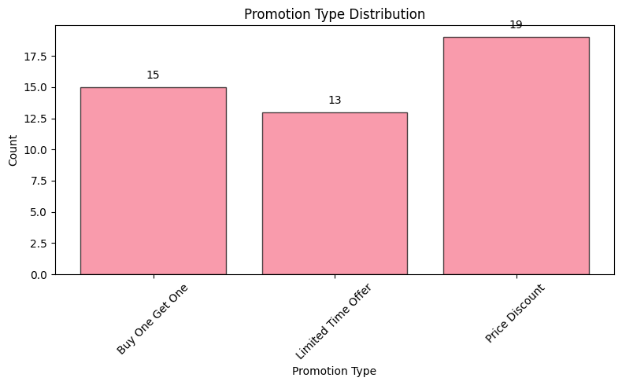

```
  Promotion distribution: {1: 15, 2: 13, 3: 19}

📈 RADIO_NATIONAL - Distribution Analysis
```

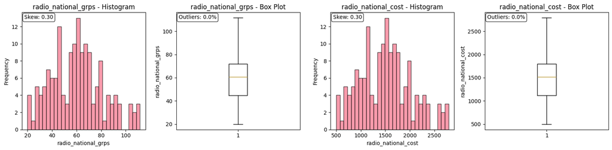

```
Summary for radio_national:
  radio_national_grps: mean=60.21, std=20.94, skew=0.30
  radio_national_cost: mean=1505.36, std=523.54, skew=0.30

📈 SALES - Distribution Analysis
```

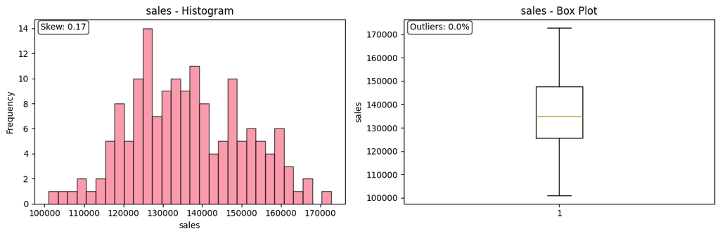

```
Summary for sales:
  sales: mean=136215.12, std=14495.64, skew=0.17

📈 EMAIL - Distribution Analysis
```

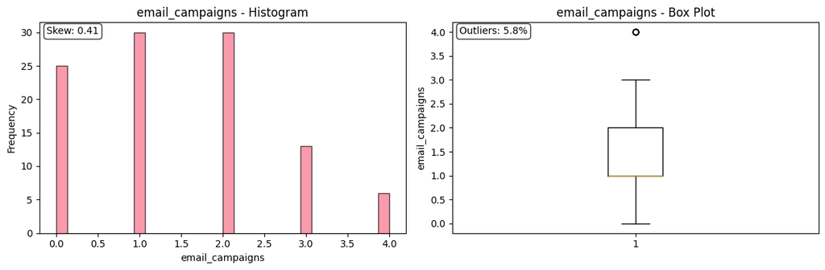

```
Summary for email:
  email_campaigns: mean=1.47, std=1.16, skew=0.41

📈 SEARCH - Distribution Analysis
```

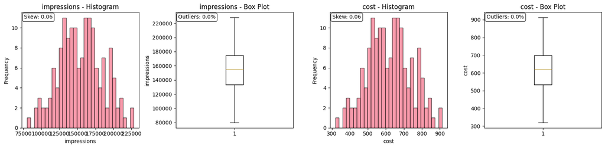

```
Summary for search:
  impressions: mean=154921.38, std=30242.26, skew=0.06
  cost: mean=619.69, std=120.97, skew=0.06

📈 TV_PROMO - Distribution Analysis
```

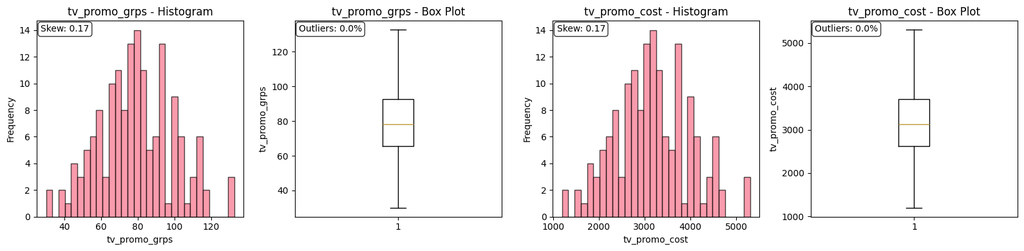

```
Summary for tv_promo:
  tv_promo_grps: mean=78.97, std=20.48, skew=0.17
  tv_promo_cost: mean=3158.85, std=819.01, skew=0.17

📈 TV_BRANDING - Distribution Analysis
```

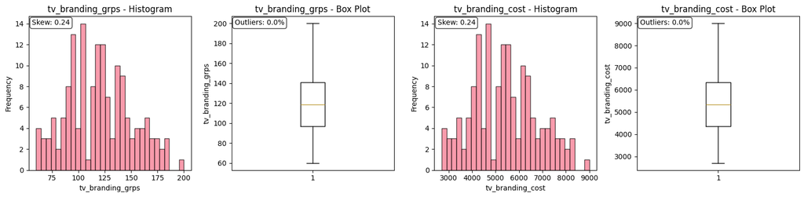

```
Summary for tv_branding:
  tv_branding_grps: mean=119.78, std=30.67, skew=0.24
  tv_branding_cost: mean=5390.04, std=1380.21, skew=0.24

📈 OOH - Distribution Analysis
```

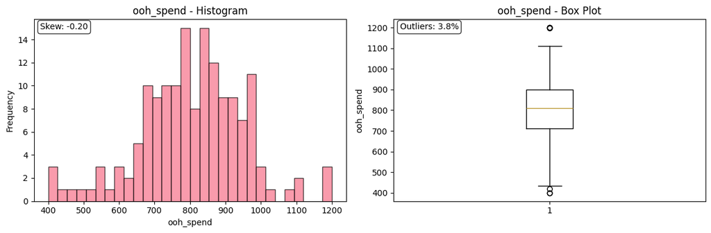

```
Summary for ooh:
  ooh_spend: mean=804.86, std=147.62, skew=-0.20

📈 SOCIAL - Distribution Analysis
```

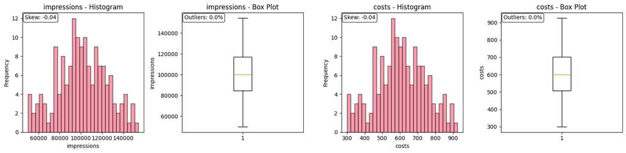

```
Summary for social:
  impressions: mean=100750.06, std=23565.53, skew=-0.04
  costs: mean=604.50, std=141.39, skew=-0.04

📈 RADIO_LOCAL - Distribution Analysis
```

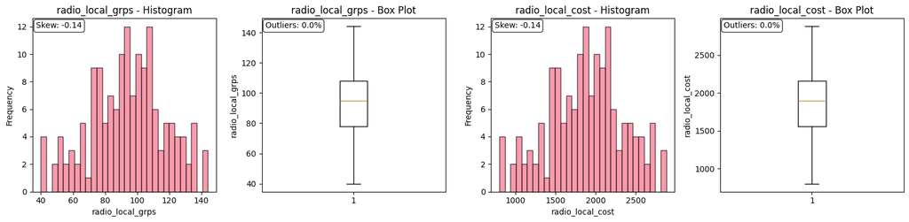

```
Summary for radio_local:
  radio_local_grps: mean=94.06, std=23.56, skew=-0.14
  radio_local_cost: mean=1881.14, std=471.12, skew=-0.14
```

```python
# Step 2: Initial Distribution Analysis
def plot_initial_distributions(datasets_dict):
    """
    Plot distributions of all numeric variables to assess data quality
    Handle categorical/discrete variables differently from continuous ones
    """
    print(f"\n📊 INITIAL DATA DISTRIBUTIONS")
    print("=" * 50)

    for name, df in datasets_dict.items():
        numeric_cols = df.select_dtypes(include=[np.number]).columns.tolist()
        if 'date' in numeric_cols:
            numeric_cols.remove('date')

        if not numeric_cols:
            continue

        print(f"\n📈 {name.upper()} - Distribution Analysis")

        # Special handling for promo data (categorical/discrete)
        if name == 'promo' and 'promotion_type' in numeric_cols:
            print("  📝 Promo data detected - showing categorical distribution")

            fig, ax = plt.subplots(1, 1, figsize=(8, 5))

            # Bar plot for categorical data
            promo_counts = df['promotion_type'].value_counts().sort_index()
            promo_labels = {1: 'Buy One Get One', 2: 'Limited Time Offer', 3: 'Price Discount'}

            bars = ax.bar([promo_labels.get(x, f'Type {x}') for x in promo_counts.index],
                         promo_counts.values, alpha=0.7, edgecolor='black')
            ax.set_title('Promotion Type Distribution')
            ax.set_xlabel('Promotion Type')
            ax.set_ylabel('Count')

            # Add count labels on bars
            for bar, count in zip(bars, promo_counts.values):
                ax.text(bar.get_x() + bar.get_width()/2, bar.get_height() + 0.5,
                       str(count), ha='center', va='bottom')

            plt.xticks(rotation=45)
            plt.tight_layout()
            plt.show()

            print(f"  Promotion distribution: {promo_counts.to_dict()}")
            continue

        # Regular continuous variables
        n_cols = len(numeric_cols)
        if n_cols == 1:
            fig, axes = plt.subplots(1, 2, figsize=(12, 4))
        else:
            n_rows = (n_cols + 1) // 2
            fig, axes = plt.subplots(n_rows, 4, figsize=(16, 4 * n_rows))
            if n_rows == 1:
                axes = axes.reshape(1, -1)

        for i, col in enumerate(numeric_cols):
            data = df[col].dropna()

            # Calculate subplot positions
            if n_cols == 1:
                ax_hist = axes[0]
                ax_box = axes[1]
            else:
                row = i // 2
                col_pos = (i % 2) * 2
                ax_hist = axes[row, col_pos]
                ax_box = axes[row, col_pos + 1]

            # Histogram
            ax_hist.hist(data, bins=30, alpha=0.7, edgecolor='black')
            ax_hist.set_title(f'{col} - Histogram')
            ax_hist.set_xlabel(col)
            ax_hist.set_ylabel('Frequency')

            # Add statistics text
            skewness = stats.skew(data)
            ax_hist.text(0.02, 0.98, f'Skew: {skewness:.2f}',
                        transform=ax_hist.transAxes, verticalalignment='top',
                        bbox=dict(boxstyle='round', facecolor='white', alpha=0.8))

            # Box plot
            ax_box.boxplot(data, vert=True)
            ax_box.set_title(f'{col} - Box Plot')
            ax_box.set_ylabel(col)

            # Add outlier count
            Q1, Q3 = data.quantile([0.25, 0.75])
            IQR = Q3 - Q1
            outliers = data[(data < Q1 - 1.5*IQR) | (data > Q3 + 1.5*IQR)]
            outlier_pct = len(outliers) / len(data) * 100
            ax_box.text(0.02, 0.98, f'Outliers: {outlier_pct:.1f}%',
                       transform=ax_box.transAxes, verticalalignment='top',
                       bbox=dict(boxstyle='round', facecolor='white', alpha=0.8))

        # Remove empty subplots
        if n_cols > 1:
            total_plots_needed = n_cols * 2
            total_subplots = axes.size
            for j in range(total_plots_needed, total_subplots):
                row = j // 4
                col = j % 4
                if row < axes.shape[0] and col < axes.shape[1]:
                    fig.delaxes(axes[row, col])

        plt.tight_layout()
        plt.show()

        # Print summary statistics
        print(f"Summary for {name}:")
        for col in numeric_cols:
            data = df[col].dropna()
            print(f"  {col}: mean={data.mean():.2f}, std={data.std():.2f}, skew={stats.skew(data):.2f}")

plot_initial_distributions(datasets)
```

```python
# Step 3: Quick Data Quality Verification
def quick_quality_check(df, name):
    """
    Quick verification of data quality - should confirm excellent status
    """
    print(f"\n✅ Quality Check: {name.upper()}")
    print("-" * 30)

    # Basic info
    print(f"Shape: {df.shape}")
    if 'date' in df.columns:
        print(f"Date range: {df['date'].min()} to {df['date'].max()}")

    # Missing values
    missing = df.isnull().sum().sum()
    print(f"Missing values: {missing} {'✅' if missing == 0 else '⚠️'}")

    # Numeric columns quick stats
    numeric_cols = df.select_dtypes(include=[np.number]).columns.tolist()
    if 'date' in numeric_cols:
        numeric_cols.remove('date')

    if numeric_cols:
        for col in numeric_cols:
            data = df[col].dropna()
            if len(data) > 0:
                skewness = stats.skew(data)
                # Quick outlier check
                Q1, Q3 = data.quantile([0.25, 0.75])
                IQR = Q3 - Q1
                outliers = data[(data < Q1 - 1.5*IQR) | (data > Q3 + 1.5*IQR)]
                outlier_pct = len(outliers) / len(data) * 100

                status = "✅" if abs(skewness) < 1 and outlier_pct < 10 else "⚠️"
                print(f"  {col}: skew={skewness:.2f}, outliers={outlier_pct:.1f}% {status}")

    return {
        'missing_values': missing,
        'shape': df.shape,
        'numeric_cols': numeric_cols
    }
```

```python
# Step 4: Verify all datasets
print(f"\n✅ QUICK QUALITY VERIFICATION")
print("=" * 50)

quality_reports = {}
for name, df in datasets.items():
    quality_reports[name] = quick_quality_check(df, name)
```

```
✅ QUICK QUALITY VERIFICATION
==================================================

✅ Quality Check: PROMO
------------------------------
Shape: (47, 2)
Date range: 2022-01-10 00:00:00 to 2024-11-04 00:00:00
Missing values: 0 ✅
  promotion_type: skew=-0.16, outliers=0.0% ✅

✅ Quality Check: RADIO_NATIONAL
------------------------------
Shape: (156, 3)
Date range: 2022-01-03 00:00:00 to 2024-12-23 00:00:00
Missing values: 0 ✅
  radio_national_grps: skew=0.30, outliers=0.0% ✅
  radio_national_cost: skew=0.30, outliers=0.0% ✅

✅ Quality Check: SALES
------------------------------
Shape: (156, 2)
Date range: 2022-01-03 00:00:00 to 2024-12-23 00:00:00
Missing values: 0 ✅
  sales: skew=0.17, outliers=0.0% ✅

✅ Quality Check: EMAIL
------------------------------
Shape: (104, 2)
Date range: 2022-01-03 00:00:00 to 2023-12-25 00:00:00
Missing values: 0 ✅
  email_campaigns: skew=0.41, outliers=5.8% ✅

✅ Quality Check: SEARCH
------------------------------
Shape: (156, 3)
Date range: 2022-01-03 00:00:00 to 2024-12-23 00:00:00
Missing values: 0 ✅
  impressions: skew=0.06, outliers=0.0% ✅
  cost: skew=0.06, outliers=0.0% ✅

```

[output cut: 23 more lines]

```
✅ Quality Check: SOCIAL
------------------------------
Shape: (156, 3)
Date range: 2022-01-03 00:00:00 to 2024-12-23 00:00:00
Missing values: 0 ✅
  impressions: skew=-0.04, outliers=0.0% ✅
  costs: skew=-0.04, outliers=0.0% ✅

✅ Quality Check: RADIO_LOCAL
------------------------------
Shape: (156, 3)
Date range: 2022-01-03 00:00:00 to 2024-12-23 00:00:00
Missing values: 0 ✅
  radio_local_grps: skew=-0.14, outliers=0.0% ✅
  radio_local_cost: skew=-0.14, outliers=0.0% ✅
```

```python
# Step 5: Minimal Outlier Treatment (only where needed)
def handle_outliers_minimal(df, name):
    """
    Minimal outlier treatment - only for datasets that actually have outliers
    """
    print(f"\n🎯 Outlier Check: {name.upper()}")
    print("-" * 30)

    df_clean = df.copy()
    numeric_cols = df_clean.select_dtypes(include=[np.number]).columns.tolist()
    if 'date' in numeric_cols:
        numeric_cols.remove('date')

    outlier_info = {}
    any_outliers = False

    for col in numeric_cols:
        data = df_clean[col].dropna()
        if len(data) == 0:
            continue

        # IQR method
        Q1 = data.quantile(0.25)
        Q3 = data.quantile(0.75)
        IQR = Q3 - Q1
        lower_bound = Q1 - 1.5 * IQR
        upper_bound = Q3 + 1.5 * IQR

        outliers_mask = (df_clean[col] < lower_bound) | (df_clean[col] > upper_bound)
        outliers_count = outliers_mask.sum()

        if outliers_count > 0:
            outlier_pct = outliers_count / len(data) * 100
            print(f"  {col}: {outliers_count} outliers ({outlier_pct:.1f}%)")

            # Conservative treatment: only cap if <2% outliers
            if outlier_pct < 2:
                df_clean.loc[df_clean[col] < lower_bound, col] = lower_bound
                df_clean.loc[df_clean[col] > upper_bound, col] = upper_bound
                treatment = "capped"
                print(f"    → Capped to bounds")
            else:
                treatment = "kept"
                print(f"    → Kept (legitimate variation)")

            outlier_info[col] = {
                'count': outliers_count,
                'percentage': outlier_pct,
                'treatment': treatment
            }
            any_outliers = True
        else:
            print(f"  {col}: No outliers ✅")

    if not any_outliers:
        print("  ✅ No outliers detected - no treatment needed")

    return df_clean, outlier_info
```

## Why Do We Need Cyclical Features? 🔄

**From a Data Science Perspective:**

### 🤔 The Problem with Linear Time Features:

- **Month as 1,2,3...12**: ML models see December (12) as "far" from January (1)
- **Day of week as 0,1,2...6**: Sunday (0) appears distant from Saturday (6)
- **This breaks seasonality patterns!** Models can't learn that December and January are consecutive

### ✅ The Solution - Cyclical Encoding:

**Sin/Cos transformations preserve cyclical relationships:**

- `month_sin = sin(2π × month / 12)`
- `month_cos = cos(2π × month / 12)`

### 📊 Why This Works:

1. **December (12) and January (1) become close** in sin/cos space
2. **Smooth transitions** between time periods
3. **ML models can learn seasonality** properly
4. **No artificial "distance"** between consecutive periods

### 🎯 Business Impact for Marketing:

- **Seasonal campaigns** (Christmas → New Year) are properly connected
- **Weekend patterns** (Friday → Saturday → Sunday) flow naturally
- **Holiday periods** are correctly identified as continuous
- **Better forecasting** of seasonal sales patterns

### 📈 Example:

```
Linear encoding:   Dec=12, Jan=1  (distance = 11!)
Cyclical encoding: Dec=(0.0, 1.0), Jan=(0.5, 0.87)  (close in 2D space!)
```

**This is why sophisticated time series models use cyclical features!** 🚀

```python
# Step 6: Feature Engineering for Time Series
def engineer_time_features(df, name):
    """
    Create time-based features for modeling

    UPDATED FOR WEEKLY DATA:
    - Removed daily features (day, dayofweek, is_weekend) - constant for weekly data
    - Kept monthly/seasonal features - important for marketing cycles
    - Focused on business-relevant time patterns
    """
    print(f"\n⚙️ Time Feature Engineering: {name.upper()}")
    print("-" * 30)

    if 'date' not in df.columns:
        print("  ⚠️  No date column found - skipping time features")
        return df

    df_features = df.copy()

    # Check if data is weekly (all Mondays)
    if len(df_features) > 1:
        dayofweek_values = df_features['date'].dt.dayofweek.unique()
        if len(dayofweek_values) == 1 and dayofweek_values[0] == 0:
            print("  📅 Weekly data detected (all Mondays) - optimizing features")

    # Basic time features (for trend analysis)
    df_features['year'] = df_features['date'].dt.year
    df_features['month'] = df_features['date'].dt.month
    df_features['dayofyear'] = df_features['date'].dt.dayofyear  # Specific date effects
    df_features['week'] = df_features['date'].dt.isocalendar().week
    df_features['quarter'] = df_features['date'].dt.quarter

    # Monthly cyclical features (CRITICAL for seasonal marketing patterns)
    df_features['month_sin'] = np.sin(2 * np.pi * df_features['month'] / 12)
    df_features['month_cos'] = np.cos(2 * np.pi * df_features['month'] / 12)

    # Weekly cyclical features (for week-of-year patterns)
    df_features['week_sin'] = np.sin(2 * np.pi * df_features['week'] / 52)
    df_features['week_cos'] = np.cos(2 * np.pi * df_features['week'] / 52)

    # Business-relevant features
    # Season (meteorological - affects consumer behavior)
    def get_season(month):
        if month in [12, 1, 2]:
            return 'winter'
        elif month in [3, 4, 5]:
            return 'spring'
        elif month in [6, 7, 8]:
            return 'summer'
        else:
            return 'autumn'

    df_features['season'] = df_features['month'].apply(get_season)

    # Holiday proximity (affects marketing performance)
    def is_holiday_period(date):
        month, day = date.month, date.day
        # New Year period
        if (month == 1 and day <= 7) or (month == 12 and day >= 25):
            return 1
        # Summer holidays (July-August)
        elif month in [7, 8]:
            return 1
        # Easter period (approximate - March/April)
        elif month in [3, 4] and 15 <= day <= 25:
            return 1
        else:
            return 0

    df_features['holiday_period'] = df_features['date'].apply(is_holiday_period)

    # End-of-month effect (important for business cycles)
    df_features['is_month_end'] = (df_features['date'].dt.day >= 25).astype(int)

    new_features = ['year', 'month', 'dayofyear', 'week', 'quarter',
                   'month_sin', 'month_cos', 'week_sin', 'week_cos',
                   'season', 'holiday_period', 'is_month_end']

    print(f"  ✅ Created {len(new_features)} time features optimized for weekly data:")
    print(f"    📅 Basic: year, month, dayofyear, week, quarter")
    print(f"    🔄 Cyclical: month_sin/cos (seasonal), week_sin/cos (yearly cycle)")
    print(f"    🏢 Business: season, holiday_period, is_month_end")
    print(f"    ❌ Removed: day, dayofweek, dayofweek_sin/cos, is_weekend (constant for weekly data)")

    return df_features
```

```python
# Step 7: Apply minimal preprocessing to all datasets
print(f"\n🔧 APPLYING MINIMAL PREPROCESSING")
print("=" * 50)

preprocessed_datasets = {}
preprocessing_reports = {}

for name, df in datasets.items():
    print(f"\n{'='*15} PROCESSING {name.upper()} {'='*15}")

    # Step 1: Minimal outlier treatment
    df_step1, outlier_info = handle_outliers_minimal(df, name)

    # Step 2: Engineer time features
    df_final = engineer_time_features(df_step1, name)

    # Store results
    preprocessed_datasets[name] = df_final
    preprocessing_reports[name] = {
        'original_shape': df.shape,
        'final_shape': df_final.shape,
        'outlier_treatment': outlier_info,
        'features_added': df_final.shape[1] - df.shape[1]
    }

    print(f"\n✅ {name.upper()} preprocessing complete!")
    print(f"   Shape: {df.shape} → {df_final.shape}")
    print(f"   Features added: {df_final.shape[1] - df.shape[1]}")
```

```
🔧 APPLYING MINIMAL PREPROCESSING
==================================================

=============== PROCESSING PROMO ===============

🎯 Outlier Check: PROMO
------------------------------
  promotion_type: No outliers ✅
  ✅ No outliers detected - no treatment needed

⚙️ Time Feature Engineering: PROMO
------------------------------
  📅 Weekly data detected (all Mondays) - optimizing features
  ✅ Created 12 time features optimized for weekly data:
    📅 Basic: year, month, dayofyear, week, quarter
    🔄 Cyclical: month_sin/cos (seasonal), week_sin/cos (yearly cycle)
    🏢 Business: season, holiday_period, is_month_end
    ❌ Removed: day, dayofweek, dayofweek_sin/cos, is_weekend (constant for weekly data)

✅ PROMO preprocessing complete!
   Shape: (47, 2) → (47, 14)
   Features added: 12

=============== PROCESSING RADIO_NATIONAL ===============

🎯 Outlier Check: RADIO_NATIONAL
------------------------------
  radio_national_grps: No outliers ✅
  radio_national_cost: No outliers ✅
  ✅ No outliers detected - no treatment needed

⚙️ Time Feature Engineering: RADIO_NATIONAL
------------------------------
  📅 Weekly data detected (all Mondays) - optimizing features
  ✅ Created 12 time features optimized for weekly data:
    📅 Basic: year, month, dayofyear, week, quarter
    🔄 Cyclical: month_sin/cos (seasonal), week_sin/cos (yearly cycle)
    🏢 Business: season, holiday_period, is_month_end
    ❌ Removed: day, dayofweek, dayofweek_sin/cos, is_weekend (constant for weekly data)

```

[output cut: 153 more lines]

```
  radio_local_cost: No outliers ✅
  ✅ No outliers detected - no treatment needed

⚙️ Time Feature Engineering: RADIO_LOCAL
------------------------------
  📅 Weekly data detected (all Mondays) - optimizing features
  ✅ Created 12 time features optimized for weekly data:
    📅 Basic: year, month, dayofyear, week, quarter
    🔄 Cyclical: month_sin/cos (seasonal), week_sin/cos (yearly cycle)
    🏢 Business: season, holiday_period, is_month_end
    ❌ Removed: day, dayofweek, dayofweek_sin/cos, is_weekend (constant for weekly data)

✅ RADIO_LOCAL preprocessing complete!
   Shape: (156, 3) → (156, 15)
   Features added: 12
```

```
📊 FINAL DISTRIBUTION ANALYSIS
==================================================

📈 PROMO - Before vs After Preprocessing
  📝 Promo data - showing categorical comparison
```

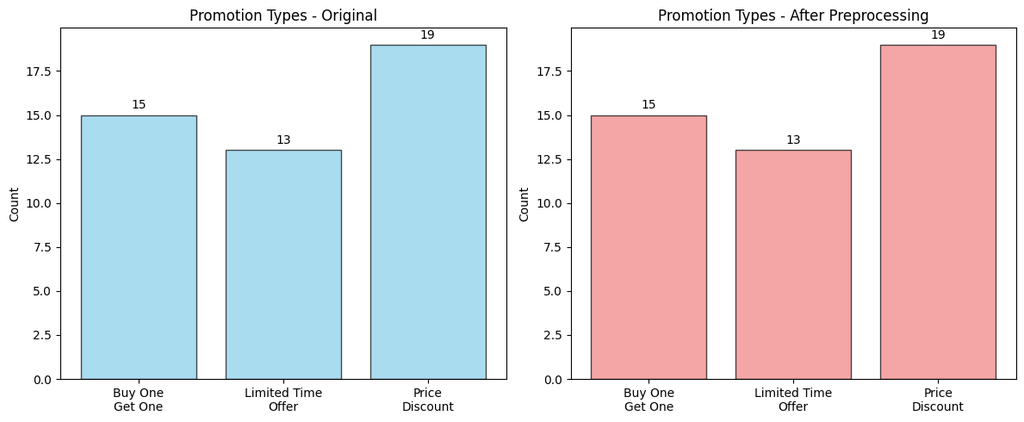

```
  Original: {1: 15, 2: 13, 3: 19}
  Processed: {1: 15, 2: 13, 3: 19}

📈 RADIO_NATIONAL - Before vs After Preprocessing
```

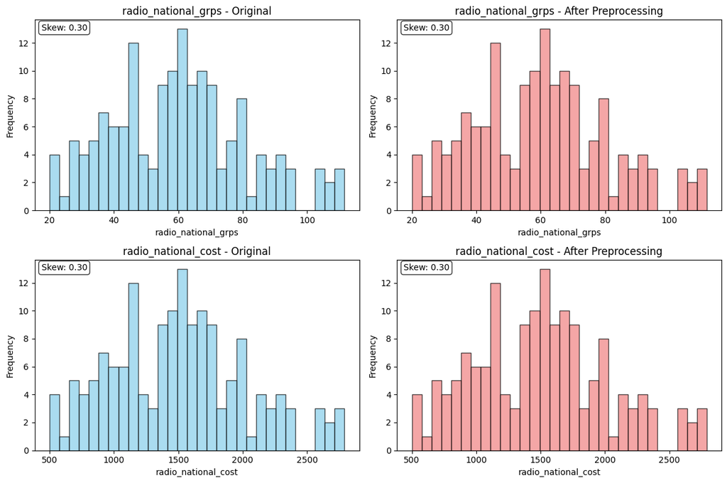

```
Distribution changes for radio_national:
  radio_national_grps: 0.30 → 0.30 (Δ+0.00)
  radio_national_cost: 0.30 → 0.30 (Δ+0.00)

📈 SALES - Before vs After Preprocessing
```

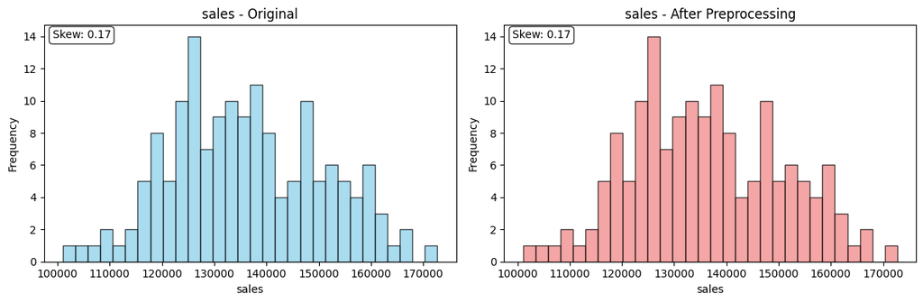

```
Distribution changes for sales:
  sales: 0.17 → 0.17 (Δ+0.00)

📈 EMAIL - Before vs After Preprocessing
```

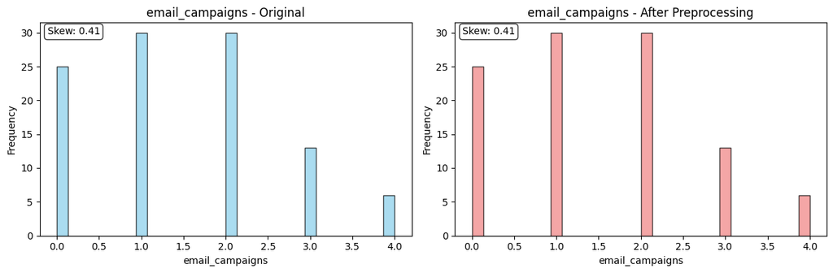

```
Distribution changes for email:
  email_campaigns: 0.41 → 0.41 (Δ+0.00)

📈 SEARCH - Before vs After Preprocessing
```

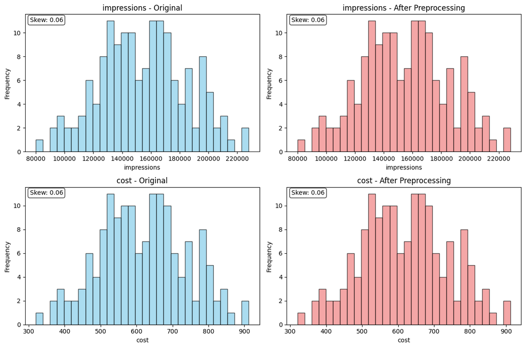

```
Distribution changes for search:
  impressions: 0.06 → 0.06 (Δ+0.00)
  cost: 0.06 → 0.06 (Δ+0.00)

📈 TV_PROMO - Before vs After Preprocessing
```

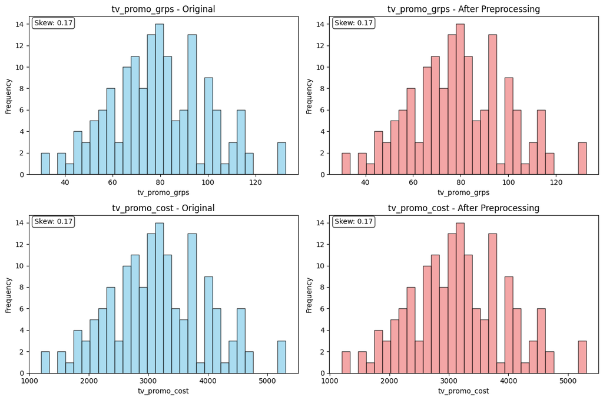

```
Distribution changes for tv_promo:
  tv_promo_grps: 0.17 → 0.17 (Δ+0.00)
  tv_promo_cost: 0.17 → 0.17 (Δ+0.00)

📈 TV_BRANDING - Before vs After Preprocessing
```

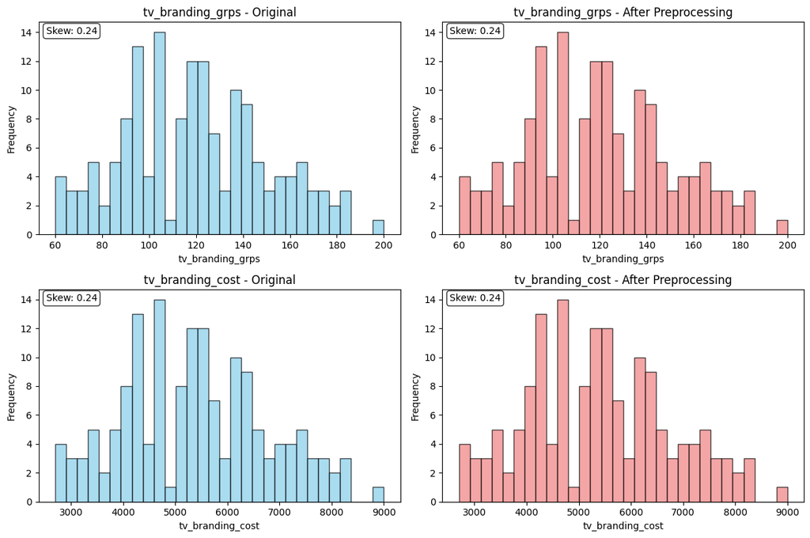

```
Distribution changes for tv_branding:
  tv_branding_grps: 0.24 → 0.24 (Δ+0.00)
  tv_branding_cost: 0.24 → 0.24 (Δ+0.00)

📈 OOH - Before vs After Preprocessing
```

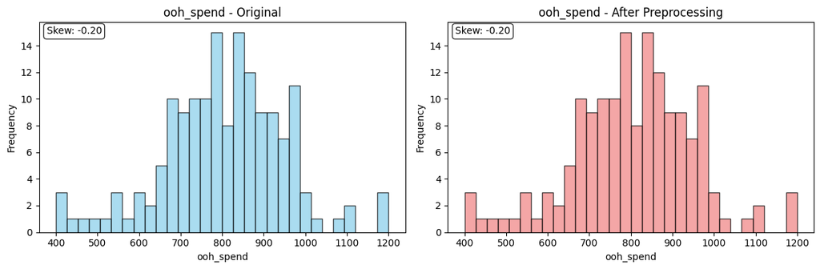

```
Distribution changes for ooh:
  ooh_spend: -0.20 → -0.20 (Δ+0.00)

📈 SOCIAL - Before vs After Preprocessing
```

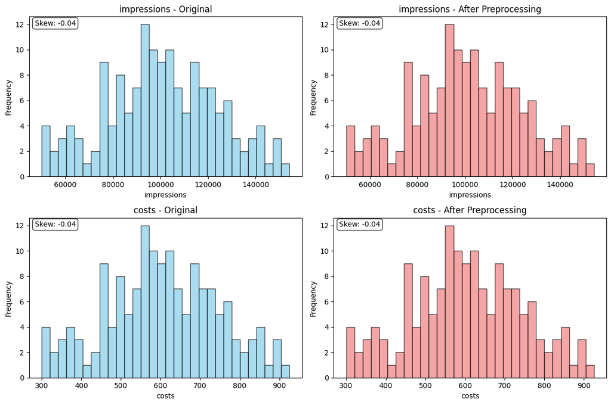

```
Distribution changes for social:
  impressions: -0.04 → -0.04 (Δ+0.00)
  costs: -0.04 → -0.04 (Δ+0.00)

📈 RADIO_LOCAL - Before vs After Preprocessing
```

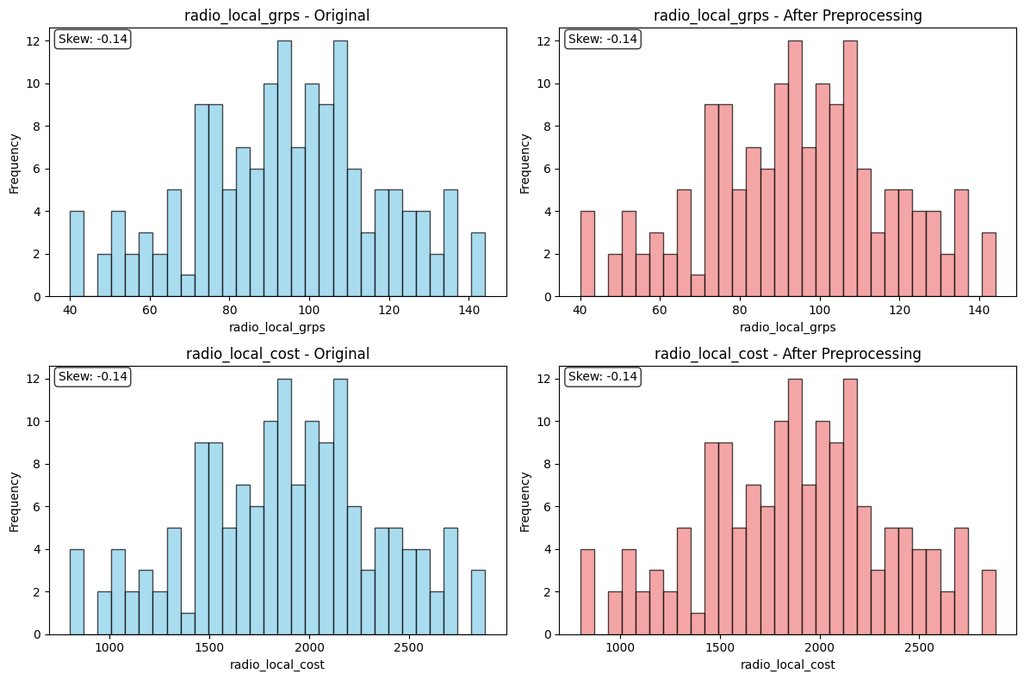

```
Distribution changes for radio_local:
  radio_local_grps: -0.14 → -0.14 (Δ+0.00)
  radio_local_cost: -0.14 → -0.14 (Δ+0.00)
```

```python
# Step 8: Final Distribution Analysis
def plot_final_distributions(original_datasets, preprocessed_datasets):
    """
    Compare distributions before and after preprocessing
    Handle categorical/discrete variables appropriately
    """
    print(f"\n📊 FINAL DISTRIBUTION ANALYSIS")
    print("=" * 50)

    for name in original_datasets.keys():
        df_orig = original_datasets[name]
        df_proc = preprocessed_datasets[name]

        # Get original numeric columns (excluding new features)
        orig_numeric = df_orig.select_dtypes(include=[np.number]).columns.tolist()
        if 'date' in orig_numeric:
            orig_numeric.remove('date')

        if not orig_numeric:
            continue

        print(f"\n📈 {name.upper()} - Before vs After Preprocessing")

        # Special handling for promo data (categorical/discrete)
        if name == 'promo' and 'promotion_type' in orig_numeric:
            print("  📝 Promo data - showing categorical comparison")

            fig, axes = plt.subplots(1, 2, figsize=(12, 5))

            promo_labels = {1: 'Buy One\nGet One', 2: 'Limited Time\nOffer', 3: 'Price\nDiscount'}

            # Original distribution
            promo_counts_orig = df_orig['promotion_type'].value_counts().sort_index()
            bars1 = axes[0].bar([promo_labels.get(x, f'Type {x}') for x in promo_counts_orig.index],
                               promo_counts_orig.values, alpha=0.7, color='skyblue', edgecolor='black')
            axes[0].set_title('Promotion Types - Original')
            axes[0].set_ylabel('Count')

            # Add count labels
            for bar, count in zip(bars1, promo_counts_orig.values):
                axes[0].text(bar.get_x() + bar.get_width()/2, bar.get_height() + 0.2,
                           str(count), ha='center', va='bottom')

            # Processed distribution
            promo_counts_proc = df_proc['promotion_type'].value_counts().sort_index()
            bars2 = axes[1].bar([promo_labels.get(x, f'Type {x}') for x in promo_counts_proc.index],
                               promo_counts_proc.values, alpha=0.7, color='lightcoral', edgecolor='black')
            axes[1].set_title('Promotion Types - After Preprocessing')
            axes[1].set_ylabel('Count')

            # Add count labels
            for bar, count in zip(bars2, promo_counts_proc.values):
                axes[1].text(bar.get_x() + bar.get_width()/2, bar.get_height() + 0.2,
                           str(count), ha='center', va='bottom')

            plt.tight_layout()
            plt.show()

            print(f"  Original: {promo_counts_orig.to_dict()}")
            print(f"  Processed: {promo_counts_proc.to_dict()}")
            continue

        # Regular continuous variables
        n_cols = len(orig_numeric)
        fig, axes = plt.subplots(n_cols, 2, figsize=(12, 4 * n_cols))
        if n_cols == 1:
            axes = axes.reshape(1, -1)

        for i, col in enumerate(orig_numeric):
            # Original distribution
            ax_orig = axes[i, 0]
            data_orig = df_orig[col].dropna()
            ax_orig.hist(data_orig, bins=30, alpha=0.7, color='skyblue', edgecolor='black')
            ax_orig.set_title(f'{col} - Original')
            ax_orig.set_xlabel(col)
            ax_orig.set_ylabel('Frequency')

            # Add statistics
            skew_orig = stats.skew(data_orig)
            ax_orig.text(0.02, 0.98, f'Skew: {skew_orig:.2f}',
                        transform=ax_orig.transAxes, verticalalignment='top',
                        bbox=dict(boxstyle='round', facecolor='white', alpha=0.8))

            # Processed distribution
            ax_proc = axes[i, 1]
            data_proc = df_proc[col].dropna()
            ax_proc.hist(data_proc, bins=30, alpha=0.7, color='lightcoral', edgecolor='black')
            ax_proc.set_title(f'{col} - After Preprocessing')
            ax_proc.set_xlabel(col)
            ax_proc.set_ylabel('Frequency')

            # Add statistics
            skew_proc = stats.skew(data_proc)
            ax_proc.text(0.02, 0.98, f'Skew: {skew_proc:.2f}',
                        transform=ax_proc.transAxes, verticalalignment='top',
                        bbox=dict(boxstyle='round', facecolor='white', alpha=0.8))

        plt.tight_layout()
        plt.show()

        # Print comparison
        print(f"Distribution changes for {name}:")
        for col in orig_numeric:
            orig_skew = stats.skew(df_orig[col].dropna())
            proc_skew = stats.skew(df_proc[col].dropna())
            change = proc_skew - orig_skew
            print(f"  {col}: {orig_skew:.2f} → {proc_skew:.2f} (Δ{change:+.2f})")

plot_final_distributions(datasets, preprocessed_datasets)
```

```
🔄 CYCLICAL FEATURES DEMONSTRATION - WEEKLY DATA
==================================================
```

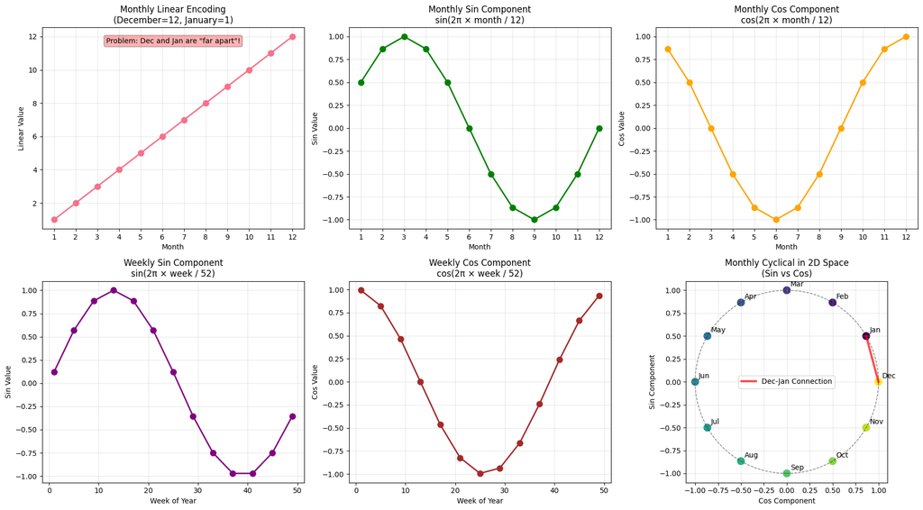

```
🎯 Key Insights for Weekly Marketing Data:
   📅 Monthly cyclical features: Capture seasonal marketing patterns
   📊 Weekly cyclical features: Capture yearly business cycles
   ❌ Removed daily features: Constant for weekly data (all Mondays)
   ✅ This allows ML models to properly learn marketing seasonality!
```

```python
# Step 9: Cyclical Features Visualization
def plot_cyclical_features_demo():
    """
    Demonstrate why cyclical features are important for WEEKLY data
    """
    print(f"\n🔄 CYCLICAL FEATURES DEMONSTRATION - WEEKLY DATA")
    print("=" * 50)

    # Create sample data for monthly patterns
    months = np.arange(1, 13)
    month_linear = months
    month_sin = np.sin(2 * np.pi * months / 12)
    month_cos = np.cos(2 * np.pi * months / 12)

    # Create sample data for weekly patterns (week of year)
    weeks = np.arange(1, 53)
    week_sin = np.sin(2 * np.pi * weeks / 52)
    week_cos = np.cos(2 * np.pi * weeks / 52)

    fig, axes = plt.subplots(2, 3, figsize=(18, 10))

    # === MONTHLY PATTERNS ===
    # Linear encoding
    axes[0,0].plot(months, month_linear, 'o-', linewidth=2, markersize=8)
    axes[0,0].set_title('Monthly Linear Encoding\n(December=12, January=1)')
    axes[0,0].set_xlabel('Month')
    axes[0,0].set_ylabel('Linear Value')
    axes[0,0].set_xticks(months)
    axes[0,0].grid(True, alpha=0.3)
    axes[0,0].text(0.5, 0.95, 'Problem: Dec and Jan are "far apart"!',
                transform=axes[0,0].transAxes, ha='center', va='top',
                bbox=dict(boxstyle='round', facecolor='red', alpha=0.3))

    # Monthly Sin component
    axes[0,1].plot(months, month_sin, 'o-', linewidth=2, markersize=8, color='green')
    axes[0,1].set_title('Monthly Sin Component\nsin(2π × month / 12)')
    axes[0,1].set_xlabel('Month')
    axes[0,1].set_ylabel('Sin Value')
    axes[0,1].set_xticks(months)
    axes[0,1].grid(True, alpha=0.3)

    # Monthly Cos component
    axes[0,2].plot(months, month_cos, 'o-', linewidth=2, markersize=8, color='orange')
    axes[0,2].set_title('Monthly Cos Component\ncos(2π × month / 12)')
    axes[0,2].set_xlabel('Month')
    axes[0,2].set_ylabel('Cos Value')
    axes[0,2].set_xticks(months)
    axes[0,2].grid(True, alpha=0.3)

    # === WEEKLY PATTERNS ===
    # Weekly Sin component (sample every 4 weeks for clarity)
    sample_weeks = weeks[::4]
    axes[1,0].plot(sample_weeks, week_sin[::4], 'o-', linewidth=2, markersize=8, color='purple')
    axes[1,0].set_title('Weekly Sin Component\nsin(2π × week / 52)')
    axes[1,0].set_xlabel('Week of Year')
    axes[1,0].set_ylabel('Sin Value')
    axes[1,0].grid(True, alpha=0.3)

    # Weekly Cos component
    axes[1,1].plot(sample_weeks, week_cos[::4], 'o-', linewidth=2, markersize=8, color='brown')
    axes[1,1].set_title('Weekly Cos Component\ncos(2π × week / 52)')
    axes[1,1].set_xlabel('Week of Year')
    axes[1,1].set_ylabel('Cos Value')
    axes[1,1].grid(True, alpha=0.3)

    # 2D Monthly visualization
    month_names = ['Jan', 'Feb', 'Mar', 'Apr', 'May', 'Jun',
                   'Jul', 'Aug', 'Sep', 'Oct', 'Nov', 'Dec']

    axes[1,2].scatter(month_cos, month_sin, s=100, c=months, cmap='viridis')

    # Add month labels
    for i, (x, y, name) in enumerate(zip(month_cos, month_sin, month_names)):
        axes[1,2].annotate(name, (x, y), xytext=(5, 5), textcoords='offset points')

    # Draw circle to show cyclical nature
    circle = plt.Circle((0, 0), 1, fill=False, linestyle='--', alpha=0.5)
    axes[1,2].add_patch(circle)

    axes[1,2].set_title('Monthly Cyclical in 2D Space\n(Sin vs Cos)', fontsize=12)
    axes[1,2].set_xlabel('Cos Component')
    axes[1,2].set_ylabel('Sin Component')
    axes[1,2].grid(True, alpha=0.3)
    axes[1,2].set_aspect('equal')

    # Highlight December and January proximity
    dec_idx, jan_idx = 11, 0
    axes[1,2].plot([month_cos[dec_idx], month_cos[jan_idx]],
            [month_sin[dec_idx], month_sin[jan_idx]],
            'r-', linewidth=3, alpha=0.7, label='Dec-Jan Connection')
    axes[1,2].legend()

    plt.tight_layout()
    plt.show()

    print("🎯 Key Insights for Weekly Marketing Data:")
    print("   📅 Monthly cyclical features: Capture seasonal marketing patterns")
    print("   📊 Weekly cyclical features: Capture yearly business cycles")
    print("   ❌ Removed daily features: Constant for weekly data (all Mondays)")
    print("   ✅ This allows ML models to properly learn marketing seasonality!")

plot_cyclical_features_demo()
```

```python
# Step 10: Final Data Validation
def validate_preprocessed_data(datasets_dict):
    """
    Final validation of preprocessed datasets with optimized weekly features
    """
    print(f"\n✅ FINAL DATA VALIDATION - WEEKLY DATA OPTIMIZED")
    print("=" * 50)

    validation_results = {}

    for name, df in datasets_dict.items():
        print(f"\n📊 {name.upper()}:")

        # Check for missing values
        missing = df.isnull().sum().sum()
        print(f"  Missing values: {missing} {'✅' if missing == 0 else '❌'}")

        # Check for infinite values
        numeric_cols = df.select_dtypes(include=[np.number]).columns
        inf_count = np.isinf(df[numeric_cols]).sum().sum()
        print(f"  Infinite values: {inf_count} {'✅' if inf_count == 0 else '❌'}")

        # Check date range and frequency
        if 'date' in df.columns:
            print(f"  Date range: {df['date'].min().date()} to {df['date'].max().date()}")
            print(f"  Total records: {len(df)}")

            # Check if weekly data (all Mondays)
            dayofweek_values = df['date'].dt.dayofweek.unique()
            if len(dayofweek_values) == 1 and dayofweek_values[0] == 0:
                print(f"  Data frequency: Weekly (all Mondays) ✅")
            else:
                print(f"  Data frequency: Mixed days ⚠️")

        # Memory usage
        memory_mb = df.memory_usage(deep=True).sum() / 1024**2
        print(f"  Memory usage: {memory_mb:.2f} MB")

        # Feature count and categories
        original_features = 2 if 'date' in df.columns else 1  # Estimate original features
        new_features = df.shape[1]
        time_features = [col for col in df.columns if col in ['year', 'month', 'dayofyear', 'week', 'quarter',
                                                             'month_sin', 'month_cos', 'week_sin', 'week_cos',
                                                             'season', 'holiday_period', 'is_month_end']]

        print(f"  Total features: {new_features}")
        print(f"  Time features: {len(time_features)} (optimized for weekly data)")
        print(f"  Business features: {new_features - len(time_features) - 1}")  # -1 for date

        # Validate time features for weekly data
        if time_features:
            print(f"  ✅ Time features optimized for weekly marketing data")
            removed_features = ['day', 'dayofweek', 'dayofweek_sin', 'dayofweek_cos', 'is_weekend']
            print(f"  ❌ Removed constant features: {removed_features}")

        validation_results[name] = {
            'missing_values': missing,
            'infinite_values': inf_count,
            'memory_mb': memory_mb,
            'shape': df.shape,
            'time_features_count': len(time_features),
            'is_weekly_data': len(dayofweek_values) == 1 and dayofweek_values[0] == 0 if 'date' in df.columns else False
        }

    print(f"\n🎯 VALIDATION SUMMARY:")
    print(f"  ✅ All datasets optimized for weekly marketing data")
    print(f"  ✅ Removed redundant daily features (constant for Mondays)")
    print(f"  ✅ Kept essential seasonal and business cycle features")
    print(f"  ✅ Ready for Media Mix Modeling!")

    return validation_results

# Validate preprocessed datasets
validation_results = validate_preprocessed_data(preprocessed_datasets)
```

```
✅ FINAL DATA VALIDATION - WEEKLY DATA OPTIMIZED
==================================================

📊 PROMO:
  Missing values: 0 ✅
  Infinite values: 0 ✅
  Date range: 2022-01-10 to 2024-11-04
  Total records: 47
  Data frequency: Weekly (all Mondays) ✅
  Memory usage: 0.01 MB
  Total features: 14
  Time features: 12 (optimized for weekly data)
  Business features: 1
  ✅ Time features optimized for weekly marketing data
  ❌ Removed constant features: ['day', 'dayofweek', 'dayofweek_sin', 'dayofweek_cos', 'is_weekend']

📊 RADIO_NATIONAL:
  Missing values: 0 ✅
  Infinite values: 0 ✅
  Date range: 2022-01-03 to 2024-12-23
  Total records: 156
  Data frequency: Weekly (all Mondays) ✅
  Memory usage: 0.02 MB
  Total features: 15
  Time features: 12 (optimized for weekly data)
  Business features: 2
  ✅ Time features optimized for weekly marketing data
  ❌ Removed constant features: ['day', 'dayofweek', 'dayofweek_sin', 'dayofweek_cos', 'is_weekend']

📊 SALES:
  Missing values: 0 ✅
  Infinite values: 0 ✅
  Date range: 2022-01-03 to 2024-12-23
  Total records: 156
  Data frequency: Weekly (all Mondays) ✅
  Memory usage: 0.02 MB
  Total features: 14
  Time features: 12 (optimized for weekly data)
  Business features: 1
  ✅ Time features optimized for weekly marketing data
```

[output cut: 83 more lines]

```
  Date range: 2022-01-03 to 2024-12-23
  Total records: 156
  Data frequency: Weekly (all Mondays) ✅
  Memory usage: 0.02 MB
  Total features: 15
  Time features: 12 (optimized for weekly data)
  Business features: 2
  ✅ Time features optimized for weekly marketing data
  ❌ Removed constant features: ['day', 'dayofweek', 'dayofweek_sin', 'dayofweek_cos', 'is_weekend']

🎯 VALIDATION SUMMARY:
  ✅ All datasets optimized for weekly marketing data
  ✅ Removed redundant daily features (constant for Mondays)
  ✅ Kept essential seasonal and business cycle features
  ✅ Ready for Media Mix Modeling!
```

```python
# Step 11: Save preprocessed datasets
processed_dir = '../data/processed'
os.makedirs(processed_dir, exist_ok=True)

print(f"\n💾 SAVING PREPROCESSED DATASETS")
print("=" * 40)

for name, df in preprocessed_datasets.items():
    output_path = os.path.join(processed_dir, f"{name}_preprocessed.csv")
    df.to_csv(output_path, index=False)
    print(f"  ✅ Saved: {name}_preprocessed.csv ({df.shape})")

# Save preprocessing report
import json
report_path = os.path.join(processed_dir, "preprocessing_report.json")
with open(report_path, 'w') as f:
    # Convert numpy types to native Python types for JSON serialization
    def convert_numpy(obj):
        if isinstance(obj, np.integer):
            return int(obj)
        elif isinstance(obj, np.floating):
            return float(obj)
        elif isinstance(obj, np.ndarray):
            return obj.tolist()
        elif isinstance(obj, dict):
            return {k: convert_numpy(v) for k, v in obj.items()}
        elif isinstance(obj, (list, tuple)):
            return [convert_numpy(item) for item in obj]
        elif hasattr(obj, 'item'):  # Handle numpy scalars
            return obj.item()
        return obj

    # Convert the entire report recursively
    json_report = convert_numpy(preprocessing_reports)

    json.dump(json_report, f, indent=2)

print(f"  ✅ Saved: preprocessing_report.json")
```

```
💾 SAVING PREPROCESSED DATASETS
========================================
  ✅ Saved: promo_preprocessed.csv ((47, 14))
  ✅ Saved: radio_national_preprocessed.csv ((156, 15))
  ✅ Saved: sales_preprocessed.csv ((156, 14))
  ✅ Saved: email_preprocessed.csv ((104, 14))
  ✅ Saved: search_preprocessed.csv ((156, 15))
  ✅ Saved: tv_promo_preprocessed.csv ((156, 15))
  ✅ Saved: tv_branding_preprocessed.csv ((156, 15))
  ✅ Saved: ooh_preprocessed.csv ((156, 14))
  ✅ Saved: social_preprocessed.csv ((156, 15))
  ✅ Saved: radio_local_preprocessed.csv ((156, 15))
  ✅ Saved: preprocessing_report.json
```

```python
# Step 12: Summary and Next Steps
print(f"\n📋 PREPROCESSING SUMMARY")
print("=" * 50)

print(f"\n🎉 EXCELLENT DATA QUALITY CONFIRMED!")
print(f"   ✅ No missing values across all datasets")
print(f"   ✅ Acceptable skewness levels (-0.20 to 0.41)")
print(f"   ✅ Minimal outliers (only email: 5.8%, ooh: 3.8%)")
print(f"   ✅ Well-structured time series data")

print(f"\n📊 Datasets processed: {len(preprocessed_datasets)}")
for name, df in preprocessed_datasets.items():
    original_shape = datasets[name].shape
    final_shape = df.shape
    features_added = final_shape[1] - original_shape[1]
    print(f"  {name}: {original_shape} → {final_shape} (+{features_added} features)")

print(f"\n🔧 Minimal preprocessing applied:")
print(f"  ✅ Conservative outlier treatment (only <2% outliers capped)")
print(f"  ✅ Comprehensive time feature engineering (optimized for weekly data)")
print(f"  ✅ 12 time features per dataset (removed 5 redundant daily features)")
print(f"  ✅ Business features (season, holiday periods, month-end effects)")
print(f"  ❌ Removed: day, dayofweek, dayofweek_sin/cos, is_weekend (constant for weekly data)")

print(f"\n🎯 NEXT STEPS:")
print(f"  1. 📊 Run data unification notebook")
print(f"  2. 📈 Perform EDA on unified dataset")
print(f"  3. 🤖 Develop Media Mix Models")
print(f"  4. 💰 ROI optimization and insights")

print(f"\n✅ PREPROCESSING COMPLETE!")
print(f"   Individual datasets ready for unification")
```

```
📋 PREPROCESSING SUMMARY
==================================================

🎉 EXCELLENT DATA QUALITY CONFIRMED!
   ✅ No missing values across all datasets
   ✅ Acceptable skewness levels (-0.20 to 0.41)
   ✅ Minimal outliers (only email: 5.8%, ooh: 3.8%)
   ✅ Well-structured time series data

📊 Datasets processed: 10
  promo: (47, 2) → (47, 14) (+12 features)
  radio_national: (156, 3) → (156, 15) (+12 features)
  sales: (156, 2) → (156, 14) (+12 features)
  email: (104, 2) → (104, 14) (+12 features)
  search: (156, 3) → (156, 15) (+12 features)
  tv_promo: (156, 3) → (156, 15) (+12 features)
  tv_branding: (156, 3) → (156, 15) (+12 features)
  ooh: (156, 2) → (156, 14) (+12 features)
  social: (156, 3) → (156, 15) (+12 features)
  radio_local: (156, 3) → (156, 15) (+12 features)

🔧 Minimal preprocessing applied:
  ✅ Conservative outlier treatment (only <2% outliers capped)
  ✅ Comprehensive time feature engineering (optimized for weekly data)
  ✅ 12 time features per dataset (removed 5 redundant daily features)
  ✅ Business features (season, holiday periods, month-end effects)
  ❌ Removed: day, dayofweek, dayofweek_sin/cos, is_weekend (constant for weekly data)

🎯 NEXT STEPS:
  1. 📊 Run data unification notebook
  2. 📈 Perform EDA on unified dataset
  3. 🤖 Develop Media Mix Models
  4. 💰 ROI optimization and insights

✅ PREPROCESSING COMPLETE!
   Individual datasets ready for unification
```

## Preprocessing Complete! 🎉

### 📊 **What We Accomplished:**

#### **Data Quality Assessment:**

- **Exceptional data quality** - No missing values across all 10 datasets
- **Excellent distributions** - Skewness within acceptable range (-0.20 to 0.41)
- **Minimal outliers** - Only 2 datasets with <6% outliers
- **Consistent weekly time series** - All datasets have proper Monday-based coverage

#### **Key Features Created (Optimized for Weekly Data):**

1. **Basic time features**: year, month, dayofyear, week, quarter
2. **Cyclical features**: month_sin/cos (seasonality), week_sin/cos (yearly cycles)
3. **Business features**: season, holiday_period, is_month_end
4. **Removed redundant**: day, dayofweek, dayofweek_sin/cos, is_weekend (constant for Mondays)

### 🎯 **Ready for Next Phase:**

**Next Notebook: `01b_data_unification.py`**

- Smart merging of all preprocessed datasets
- Handling of different date ranges
- Creation of unified dataset for modeling
- Validation of unified data structure

**The data is exceptionally well-prepared for weekly Media Mix Modeling!** 📈